# README

Marinus Louw

24/08/2018

# Finmx Assignments 1 & 2

Below is all the documentation towards completing assignments 1 & 2 for financial econometrics on 2018/09/05. The assignments were completed in RStudio and uploaded to a Git repository.

## Prerequisites

The following are packages that should be loaded as a prerequisite.

```r
if (!require(rmsfuns)) install.packages("rmsfuns")
library(rmsfuns)
load_pkg(c("tbl2xts","tinytex", "rmarkdown", "xts", "dplyr", "lubridate",
           "glue", "lubridate", "tibble", "readr", "tidyverse",
           "PerformanceAnalytics", "readxl", "ggthemes", "ggsci"))
```

```
## x lubridate::as.difftime() masks base::as.difftime()
```

### Preliminary Step 1

Load both the datasets

```r
# Load the datasets
  J200 <-
    read_rds("data/J200.rds")
  Daily_TRI <-
    read_rds("data/Fin_Data_SA_US_NKY.rds")
```

### Prelimanary: Step 2

Change column names and add a column that will be used later on

```r
# Adjust the J200 data to include a Year_Month column and rename the sector column
  Daily_J200_Adjusted <-
    J200 %>%
    mutate(Year_Month = format(date, "%Y%B"))
  colnames(Daily_J200_Adjusted)[colnames(Daily_J200_Adjusted)=="ICB_INDUSTRY_NAME"] <- "Sector"
# Adjust the TRI data for missing market caps and adjusted weights per ticker
  Daily_TRI_Adjusted <-
    Daily_TRI %>%
    # After having checked for unique market caps, etc. I decided to filter out all the tickers without market caps.
    # This removed all of the NA values. Since the NAs originated from missing market cap values, I continue.
    filter(Market.Cap != 0) %>%
    # Add a column to indicate the months. This will simplify calculations going forward.
    mutate(Year_Month = format(date, "%Y%B")) %>%
    # In order to caculate the cap-weighted returns, we first calculate a column for the adjusted weights.
    group_by(Universe, date) %>%
    mutate(Weight_Adj = Market.Cap/sum(Market.Cap)) %>%
    ungroup()
    # Sanity Check that the weights add up to 1 for each day.
    Daily_TRI_Adjusted %>%
    mutate(date = ymd(date)) %>%
    filter(date == ymd(20180131)) %>%
    filter(Universe %in% "JALSHAll") %>%
    select(Weight_Adj) %>%
    sum()
```

```
## [1] 1
```

```r
  # Rename the sector and industry column for ease of use.
  colnames(Daily_TRI_Adjusted)[colnames(Daily_TRI_Adjusted)=="BICS_LEVEL_1_SECTOR_NAME"] <- "Sector"
  colnames(Daily_TRI_Adjusted)[colnames(Daily_TRI_Adjusted)=="BICS_LEVEL_2_INDUSTRY_GROUP_NAME"] <- "Industry"
```

## Assignment 1:

### Question 1

Compare the Financials and Industrials returns for 2017

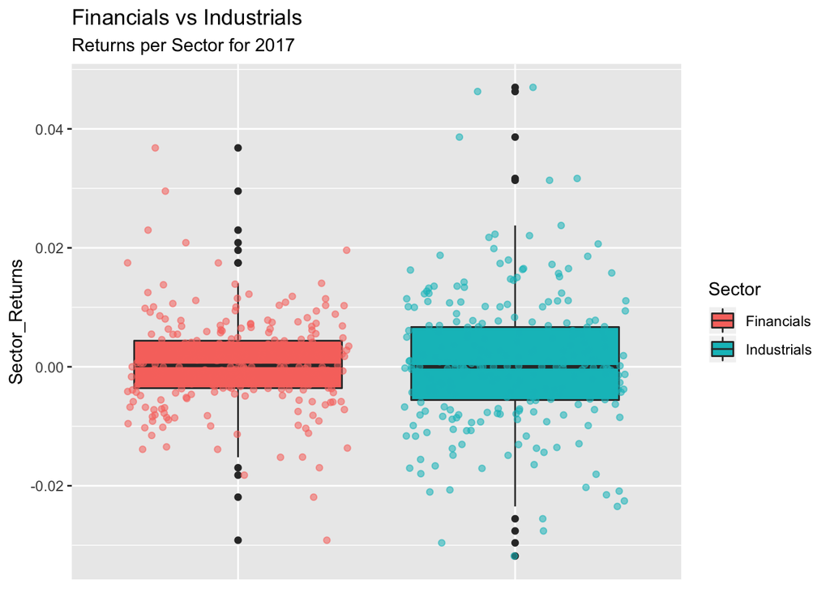

```r
# Step 1
  # Calculate a daily returns column
    Daily_Ret_J200_Adjusted <-
      Daily_J200_Adjusted %>%
      filter(Sector %in% c("Industrials","Financials")) %>%
      mutate(date = ymd(date)) %>%
      filter(date >= ymd(20170101) & date < ymd(20180101)) %>%
      group_by(Tickers) %>%
      mutate(Daily_Returns = Prices/lag(Prices) - 1) %>%
      ungroup()
# Step 2
  # Calculate the daily mean returns for each sector
    Sector_Ret_J200_Adjusted <-
      Daily_Ret_J200_Adjusted %>%
      group_by(date, Sector) %>%
      summarise(Sector_Returns = mean(Daily_Returns, na.rm = TRUE)) %>%
      ungroup()
# Step 3
  # Create a graphical illustration to compare the returns of each sector
    Sector_Ret_J200_Adjusted %>%
      ggplot() +
      geom_boxplot(aes(x = Sector, y = Sector_Returns, fill = Sector)) +
      geom_jitter(aes(x = Sector, y = Sector_Returns, color = Sector, alpha = 0.25)) +
      labs(title = "Financials vs Industrials", subtitle = "Returns per Sector for 2017") +
      theme(axis.title.x=element_blank(),axis.text.x=element_blank(),axis.ticks.x=element_blank()) +
      guides(color = FALSE, alpha = FALSE)
```

### Question 2

Find the 5 most volatile stocks for the index

```r
# Step 1
  # Create a standard deviation column to illustrate volatility
    SD_J200_Adjusted <-
      Daily_J200_Adjusted %>%
      group_by(Tickers) %>%
      mutate(Daily_Returns = Prices/lag(Prices) - 1) %>%
      mutate(Index = "J200") %>%
      group_by(Short.Name, Index) %>%
      summarise(SD = sd(Daily_Returns, na.rm = TRUE)) %>%
      ungroup()
# Step 2
  # Filter out the top 5 most volatile stocks for the index from 2017-2018
    SD_J200_Adjusted %>%
      top_n(5, SD)
```

```
## # A tibble: 5 x 3
##   Short.Name       Index     SD
##   <chr>            <chr>  <dbl>
## 1 FORTRESS REIT B  J200  0.0272
## 2 IMPALA PLATINUM  J200  0.0273
## 3 NEPI ROCKCASTLE  J200  0.0271
## 4 RESILIENT REIT L J200  0.0430
## 5 STEINHOFF INT NV J200  0.0759
```

### Question 3

Use PerformanceAnalytics and compare the maximum drawdowns of the Industrials versus the Consumer Goods sectors

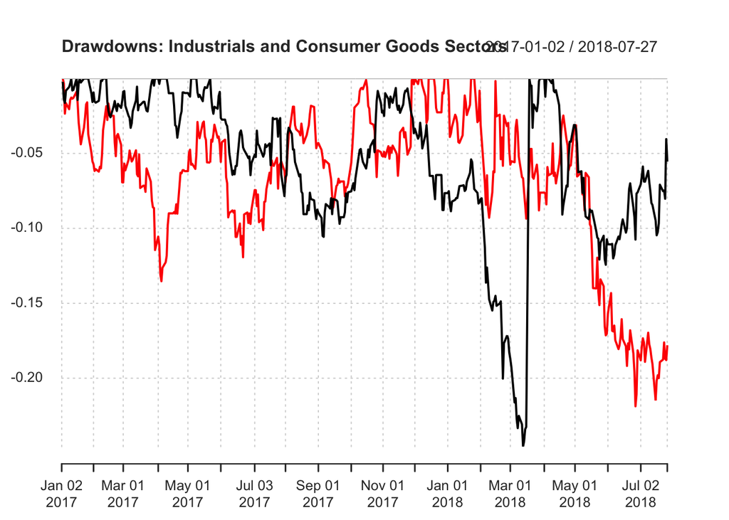

```r
# Step 1
  # Create a wide xts from summarised daily mean industry prices
    xts.Sector_Prices_J200_Adjusted <-
      Daily_J200_Adjusted %>%
      filter(Sector %in% c("Industrials","Consumer Goods")) %>%
      group_by(date, Sector) %>%
      summarise(Mean_Prices = mean(Prices, na.rm = TRUE)) %>%
      ungroup() %>%
      spread(key = Sector, value = Mean_Prices) %>%
      tbl_xts()
# Step 2
  # Use the xts package to calculate the daily sector returns
    xts.Sector_Ret_J200_Adjusted <-
      xts.Sector_Prices_J200_Adjusted %>%
      diff.xts(lag = 1, log = F, arithmetic = F) - 1
# Step 3
  # Chart the drawdowns for the Industrials and Consumer Goods sectors
    xts.Sector_Ret_J200_Adjusted %>%
      chart.Drawdown(main = "Drawdowns: Industrials and Consumer Goods Sectors")
```

## Assignment 2

### Question 1

Calculate the cap-weighted monthly index returns for every sector of each country

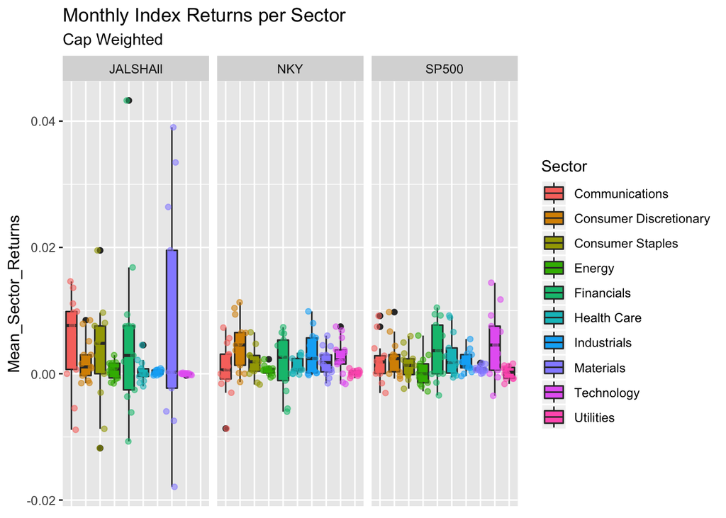

```r
# Step 1
  # Calculate the monthly returns of each stock
    Sector_Ret_Adjusted <-
      Daily_TRI_Adjusted %>%
      group_by(Year_Month, Ticker) %>%
      filter(date == last(date)) %>%
      group_by(Ticker) %>%
      mutate(Monthly_Returns = TRI/lag(TRI) - 1) %>%
# Step 2
  # Calculate the sector returns
      mutate(Monthly_Returns = coalesce(Monthly_Returns, 0)) %>%
      group_by(date, Universe, Sector) %>%
      mutate(Sector_Returns = sum(Monthly_Returns*Weight_Adj)) %>%
      summarise(Mean_Sector_Returns = mean(Sector_Returns)) %>%
      ungroup()
# Step 3
  # Create a graph that compares the sector returns for each country
    Sector_Ret_Adjusted %>%
      ggplot() +
      geom_boxplot(aes(x = Sector, y = Mean_Sector_Returns, fill = Sector)) +
      geom_jitter(aes(x = Sector, y = Mean_Sector_Returns, color = Sector, alpha = 0.25)) +
      labs(title = "Monthly Index Returns per Sector", subtitle = "Cap Weighted") +
      facet_wrap(~Universe) +
      theme(axis.title.x=element_blank(),axis.text.x=element_blank(),axis.ticks.x=element_blank()) +
      guides(color = FALSE, alpha = FALSE)
```

### Question 2

Calculate the sharpe ratio for the equally weighted by country, cap-weighted index returns since 2017

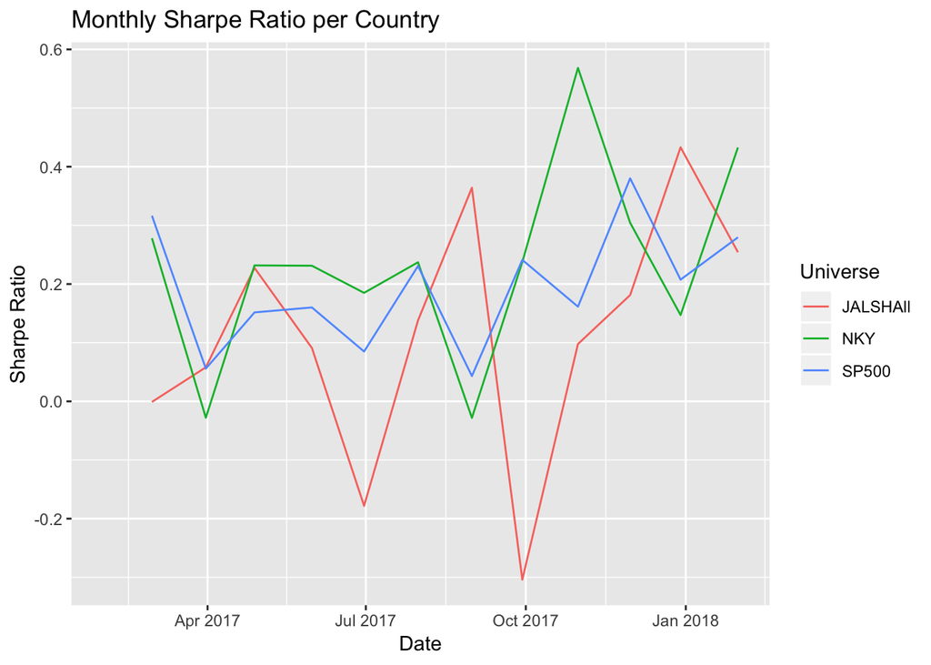

```r
# Step 1
  # Calculate the monthly returns of each stock
    Monthly_Sharpe <-
      Daily_TRI_Adjusted %>%
      group_by(Year_Month, Ticker) %>%
      filter(date == last(date)) %>%
      group_by(Ticker) %>%
      mutate(Monthly_Returns = TRI/lag(TRI) - 1) %>%
# Step 2
  # Calculate the monthly Sharpe Ratios for each country
      mutate(Monthly_Returns = coalesce(Monthly_Returns, 0)) %>%
      group_by(date, Universe) %>%
      mutate(Weighted_Returns = (Monthly_Returns*Weight_Adj)) %>%
      mutate(Index_Returns = sum(Weighted_Returns)) %>%
      mutate(Index_Returns = coalesce(Index_Returns, 0)) %>%
      summarise(Sharpe = mean(Weighted_Returns, na.rm = TRUE) / sd(Weighted_Returns, na.rm = TRUE)) %>%
      ungroup()
# Step 3
  # Create a graph that compares the monthly Sharpe ratios for each country
    Monthly_Sharpe %>%
      ggplot() +
      geom_line(aes(x = date, y = Sharpe, color = Universe)) +
      labs(title = "Monthly Sharpe Ratio per Country", x = "Date", y = "Sharpe Ratio") +
      guides(alpha = FALSE)
```

### Question 3

Plot all the cumulative returns for the Financials indexes of the three countries

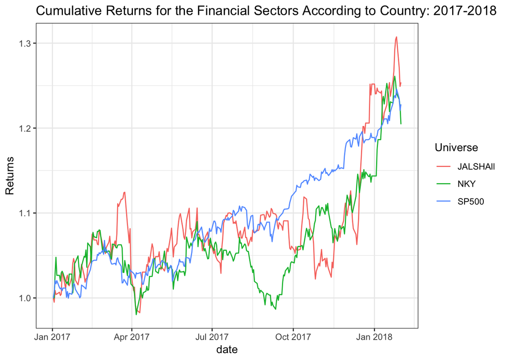

```r
# Step 1
 # Calculate Daily Returns column
    Daily_Ret_TRI_Adjusted <-
      Daily_TRI_Adjusted %>%
      group_by(Ticker) %>%
      mutate(Daily_Returns = TRI/lag(TRI) - 1) %>%
      ungroup()
# Step 2
  # Calculate the Daily Cumulative Returns Column
    Financials_CumRet_TRI_Adjusted <-
      Daily_Ret_TRI_Adjusted %>%
      arrange(date) %>%
      filter(Sector %in% "Financials") %>%
      mutate(Daily_Returns = coalesce(Daily_Returns, 0)) %>%
      group_by(Universe, Ticker) %>%
      mutate(Cum_Returns = cumprod( 1 + Daily_Returns)) %>%
      group_by(date, Universe) %>%
      summarise(Cum_Returns_Country = mean(Cum_Returns, na.rm = TRUE)) %>%
      ungroup()
# Step 3
  # Create a graph that compares the sectors according to universe
    ggplot(data = Financials_CumRet_TRI_Adjusted) +
      geom_line(aes(x = date,y = Cum_Returns_Country, color = Universe)) +
      theme_bw() + labs(title = "Cumulative Returns for the Financial Sectors According to Country: 2017-2018", y = "Returns")
```

### Question 4

Calculate the JALSH index returns, by filtering the top 95% of Market Cap

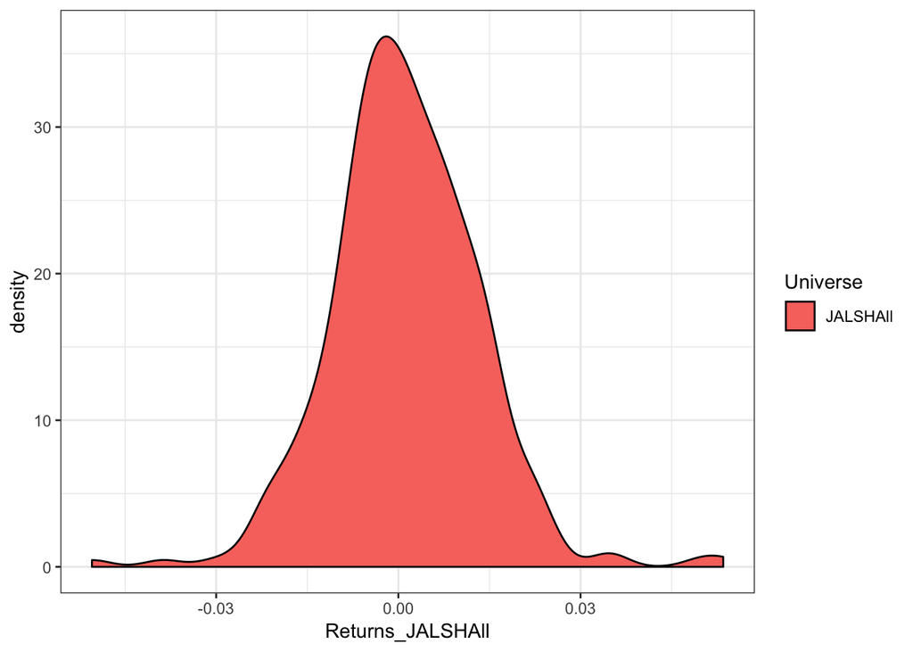

```r
# Step 1
  # Find the top 95% by market cap for the JALSH
    MrktCap_JALSH <-
      Daily_TRI_Adjusted %>%
      filter(Universe %in% "JALSHAll") %>%
      mutate(date = ymd(date)) %>%
      arrange(date, desc(Market.Cap)) %>%
      group_by(date) %>%
      mutate(Cum_MrktCap = cumsum(Market.Cap)) %>%
      mutate(Sum_MrktCap = sum(Market.Cap, na.rm = TRUE)) %>%
      mutate(Percentage_MrktCap = (Cum_MrktCap/Sum_MrktCap)*100) %>%
      ungroup() %>%
      filter(Percentage_MrktCap <= 95)
#Step 2
  # Calculate the ordinary returns for the JALSH index, filtered by top 95% of Market Cap
    Ret_MrktCap_JALSH <-
      MrktCap_JALSH %>%
      group_by(Ticker) %>%
      mutate(Daily_Returns = TRI/lag(TRI) - 1) %>%
      group_by(date, Universe) %>%
      summarise(Returns_JALSHAll = mean(Daily_Returns, na.rm = TRUE)) %>%
      ungroup()
#Step 3
  # Plot the returns for the 95% JALSH index on a histogram
    Ret_MrktCap_JALSH %>%
      ggplot() +
      geom_density(aes(x = Returns_JALSHAll, fill = Universe)) +
      theme_bw()
```

### Question 5

Calculate and visually compare the rolling 60 day standard deviation for the Materials sectors of each country

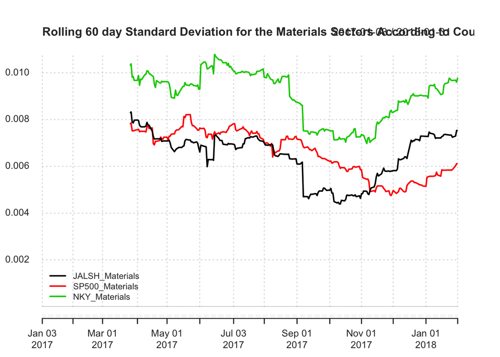

```r
#Step 1
  # Calculate Returns column
    Daily_Ret_TRI_Adjusted <-
      Daily_TRI_Adjusted %>%
      group_by(Ticker) %>%
      mutate(Daily_Returns = TRI/lag(TRI) - 1) %>%
      ungroup()
#Step 2
  # Create objects of the mean returns per Universe's Materials sector
    # JALSHAll
      JALSH_Materials <-
        Daily_Ret_TRI_Adjusted %>%
        filter(Sector %in% "Materials") %>%
        group_by(date) %>%
        summarise(JALSH_Materials = mean(Daily_Returns, na.rm = TRUE)) %>%
        ungroup()
    # SP500
      SP500_Materials <-
        Daily_Ret_TRI_Adjusted %>%
        filter(Sector %in% "Materials") %>%
        filter(Universe %in% "SP500") %>%
        group_by(date) %>%
        summarise(SP500_Materials = mean(Daily_Returns, na.rm = TRUE)) %>%
        ungroup()
    # JALSHAll
      NKY_Materials <-
        Daily_Ret_TRI_Adjusted %>%
        filter(Sector %in% "Materials") %>%
        filter(Universe %in% "NKY") %>%
        group_by(date) %>%
        summarise(NKY_Materials = mean(Daily_Returns, na.rm = TRUE)) %>%
        ungroup()
#Step 3
  # Join the 3 tibble datasets and convert it to xts
      Join_1 <- full_join(JALSH_Materials, SP500_Materials, by = "date")
      Materials.xts <- full_join(Join_1, NKY_Materials, by = "date") %>% tbl_xts
#Step 4
  # Chart
    chart.RollingPerformance(R = Materials.xts, FUN = "sd",
                           width = 60, main = "Rolling 60 day Standard Deviation for the Materials Sectors According to Country",
                           legend.loc = "bottomleft")
```